# Model description using the ODD protocol

Seyyedeh Zeinab Mousavi

Here, we provide a detailed description of the model, using the ODD (Overview, Design concepts, and Details) protocol for describing individual- and agent-based models (Grimm et al., 2006), as updated by Grimm et al. (2020).

# 1 Purpose and Patterns

We propose an abstract model to explore the application of dynamic systems theories to self-control and its development and to suggest new directions for further empirical analyses. Specifically, we aim to explain the interplay between parenting practices of autonomy support and control, with the development of self-control, using dynamic systems concepts, such as state space, attractor, and phase transition.

The pattern we aim our model to reproduce is the inverse u-shape relation between adolescents’ self-control and the extent of parents’ control and monitoring, where both permissive and authoritarian parenting with too little and too much rule-setting and supervision show a negative link with self-control in adolescents. We have extracted this pattern from the field’s literature which we discussed in detail in the introduction of the main article.

# 2 Entities, State Variables, and Scales

## 2.1 Entities

The model has two kinds of entities, the agents and the observer:

- **Observer** : We use the observer to record model outputs for further processing.
- **Agents** : There are two agents in our model:
  - Adolescent agent
  - Parent agent

The adolescent-parent pair is considered a *family unit*. Here, we have conflated both parents into a single agent, as it is common in the literature to either consider one of the parents (commonly the mother, e.g., in (Vansteenkiste et al., 2014) and (van Petegem et al., 2019)) or to combine the scores of various paternal and maternal scales into a single parenting score (e.g., Hinnant et al. (2016); Karmakar (2015); Thomas et al. (2020); Won & Yu (2018)).

## 2.2 State variables

In the ODD terminology, state variables are the variables that either distinguish one agent from the other, or specify how the entity changes over time. These variables should not be confused with the notion of states and state spaces in the dynamic systems. Nevertheless, the only state variable in our model is the adolescent agent’s state space, meaning that the values of the state space are the variables that trace the changes in the agent over time. In the following paragraphs we discuss the theoretical aspect of the state space in our model and present the technical explanations and equations in sections Update_StateVariables submodel and Choose_Next_SSP submodel.

## 2.3 Scale

Each time step in the model represents half an hour, and 24 steps represent 12 working hours within a day. We choose the total number of simulation steps, denoted by the parameter *SimDuration*, as multiplications of 24 to model them as an approximation of days. However, this definition of the time steps is arbitrary and not the main focus of our model. Moreover, we test the effects of the parameter *SimDuration* on model outcomes using systematic experiments.

# 3 Process overview and scheduling

At the start of each simulation step, the model executes the following processes in the specified order:

1. The parent agent executes Determine_Presence submodel.
2. The adolescent agent executes Determine_Compliance submodel.
3. The adolescent agent executes Execute_Action submodel.
4. The adolescent agent executes Update_StateVariables submodel
5. The adolescent agent executes Choose_Next_SSP submodel.
6. The observer executes Update_ActionsHistory submodel.

We will explain steps 1-5 in detail in the Submodels section. In the 6th step, the observer stores the executed action and its attributes in a data frame named Actions_History, which is expanded after each step to include the newly executed action (refer to the code Update_ActionsHistory.R for more detail). We later use this data to measure various model outputs.

# 4 Design concepts

## 4.1 Basic concepts

By designing this model, we aim to explore the potential of dynamic systems (DS) concepts in explaining the processes of adolescents’ self-control development in the context of family. Here, we review the theoretical basis of the model’s basic concepts. For a discussion about the background and basics of the discussed concepts, refer to the introduction of the main article.

The adolescent agent behaves based on DS concepts and self-determination theory (SDT). The agent selects goal-directed actions according to their intrinsic appeal but also considers external constraints when deciding on the execution of these actions.

The model characterizes the adolescent agent by a state space (SS). The agent’s action selection and execution shape its state space throughout the simulation.

We have conceptualized the agent’s state space as a hypothetical potential field. Researchers have used potential field representations to explain phenomena such as infant motor development (Newell et al., 2003), problem solving (Stamovlasis, 2016), and visual perception (Sandamirskaya et al., 2013). However, in methods such as dynamic field theories (Sandamirskaya et al., 2013), the potential function is explicitly formulated as a mathematical function. On the other hand, we have implemented the potential field more like an abstract representation to explore the proposed self-control development process at a qualitative level. In this regard, the value of each position/state within the state space is analogous to the value of the hypothetical potential function of the system in that state.

As discussed in the introduction of the main article, the minimums of the system’s potential field represent its attractors, which pull the system’s behavior toward themselves. Deeper potential wells represent stronger attractors, which are more stable and, thus, more resistant to perturbations. Upon entering these states, the system shows a strong tendency to act according to the associated goal. Successive execution of a goal’s action strengthens the link between the state and the executed action, i.e., deepens its attractor (refer to Update_StateVariables submodel). This deeper attractor, in turn, contributes to the likelihood of choosing the same action when positioned in the same state (refer to Select_Action function). In other words, previous successive activations facilitate the activation of new inputs. The system is also more likely to reside in one of the deeper attractors. We have implemented this process by moving the system’s new state toward the nearest local minimum (refer to Choose_Next_SSP submodel).

A critical aspect of the process of updating the system’s attractors, is the effect of autonomy. As the SS represents the tendency toward a goal, its values change based on how autonomously the agent has acted toward that goal. According to the SDT, people would be more intrinsically motivated toward a goal if it is more related to their self (integrated motivation), than when it is forced upon them (external motivation) (Ryan & Deci, 2000). We have discussed the SDT in more detail in the introduction of the main article.

## 4.2 Emergence

The main outcome of the model is the ratio of the selected LG actions after the parental monitoring has lifted. This outcome emerges as the agent chooses and executes actions during the simulation. The process of action selection and execution changes the state space, which in turn affects the action selection in the following steps. By imposing a specific limit on the execution of SG actions, the parental rule also contributes to this process.

## 4.3 Adaptation

The decision-making process in our model has no direct objective. At each step, based on probabilities derived from two internal criteria, the adolescent agent selects between two options (goals). These two criteria of the action selection process are the values of the current state in the state spaces of the agent and the intrinsic preferences of each goal.

After the initial selection process, the agent matches the selected action to the rule specified by the parent agent. The adolescent agent chooses the final option to be executed based on this match. For a more detailed description, refer to Execute_Action submodel.

## 4.4 Objectives

The agents in this model have no explicit objective.

## 4.5 Learning

As the simulation proceeds, the adolescent agent’s decisions change based on the change in the attractors of the state space. Therefore, the model implements an example of implicit learning by capturing the memory of executing an action in a specific state. Upon reentering this state, the previous activations make selecting the goal more probable than previous encounters. The processes concerning the state space and its corresponding attributes and contribution to action selection are discussed in more detail in sections Basic Concepts, Select_Action function, and Update_StateVariables submodel.

## 4.6 Prediction

We have not implemented a prediction process.

## 4.7 Sensing

In this model, the adolescent agent knows the parent agent’s absence and presence and its rule. Moreover, we assume the parent agent communicates its rule with the adolescent with enough clarity. In other words, although this is not the case in many real-world situations, there are no uncertainties regarding parental expectations in this model. Here, the aim is to focus on the rule itself and not the manners of its communication.

Moreover, the adolescent agent has an internal count of the number of steps it has complied with parental rules and the number of SG actions it has executed within those steps (for more detail, refer to the Enforce_Parental_Rule function). We also use the value of the State-Goal link of the current state in action selection, but it is assumed to be implicit.

## 4.8 Interaction

We have only implemented a one-way interaction from the parent to the adolescent agent. The parent agent sets a rule for the adolescent to follow and enforces compliance when it is present. In reality, the adolescent’s actions can also affect parental behavior, making them relax some of the rules or employ closer supervision. However, to keep the model processes as simple as possible, we have decided to ignore this reverse effect and only focus on the one-way parent-to-adolescent impact.

## 4.9 Stochasticity

Stochasticity enables us to account for variations in the system or one of its processes that we do not want to model explicitly. In this model, we have incorporated stochasticity in the following processes:

- Determining the parental presence: The aim here was to add variability. While we keep the overall probability of the parent agent being present constant throughout the simulation, the steps, where these presence states happen, are variable.
- Determining the compliance state based on parental presence: Again, the probability of compliance is determined at the beginning of the simulation and kept constant until the end. Yet, the details differ for each step as a random process assigns a value to the adolescent agent’s *Compliance_State*.
- Action selection process: In this model, we have implemented two criteria for action selection. We use these criteria as weights determining the probability of selecting each of the two actions. The aim for including this randomness is to account for the other factors affecting the action selection process that has not been explicitly modeled (for more detail, refer to Select_Action function).
- Choosing the next position in the state space: Like the previous instances, the idea here is to account for the variability of a person’s mood, motivations, and tendencies during a day (for more detail, refer to Choose_Next_SSP submodel).

## 4.10 Collectives

There are no collectives in this model.

## 4.11 Observation

The main response of the model is the ratio of the executed long-term goal actions (LGR) after the parental monitoring has lifted. As we vary the LG preference probability (LGPP) to see its effect on the outcome, we use the difference between the LGPP and the LGR as the final output of the model (LGRD). The following equation computes the LGRD in the *response steps*:

$$\small
LGRD = \frac{Number\:
of\:executed\:LG\:actions}{Total\:number\:of\:executed\:actions} - LGPP$$

Where the *Total number of executed actions* is equal to the constant *Response_Steps* (after the main body of the simulation ends, we continue the process for several steps determined by the constant *Response_Steps*. In these steps, we lift the parental rule and keep the state space of the adolescent agent constant. The aim is to provide a frozen state to compute the LGR). We count the number of the LG actions the agent has executed within these steps and use it to calculate the ratio of the executed LG actions. On the other hand, the LGPP gives us the reference point for selecting LG actions. In other words, with no other factors influencing the action selection process, the agent would choose LG action at the base rate determined by the LGPP (for more detail, refer to the Select_Action function). Therefore, we attribute the deviations from this value to the implemented processes of change in model.

# 5 Initialization

The only state variables of the model are the State-Goal links of the adolescent agent, described in State variables, which we initialize with zero. Moreover, the model does not use any external input data.

# 6 Submodels

## 6.1 Determine_Presence submodel

At each simulation step, the parent agent can either be present or absent, where being present entails actively trying to enforce the declared rule. In this submodel (refer to the code Determine_Presence.R), using the parameter *P_Probability*, a weighted random process assigns a TRUE/FALSE value to the *Presence* variable. As a result, in the *P_Probability* of the simulation steps, the *Presence* variable would be TRUE and otherwise FALSE.

## 6.2 Determine_Compliance submodel

This submodel (refer to the code Determine_Compliance.R) assigns a TRUE/FALSE value to the adolescent agent’s *Compliance_State*. When this variable is TRUE, the adolescent agent complies with the parental rule, and when it is FALSE, the agent ignores this rule.

In this model, we have implemented the parental rule-setting as setting the maximum number of SG actions that the parents allow the adolescent to execute. Here, we aim to represent different parenting styles simply by the strictness of the rule they expect the adolescent to follow. Lax rules, which hardly require the adolescent to change her behavior, represent *permissive* parenting styles, while strict rules, which leave no room for autonomous choice, resemble *authoritarian* parenting styles. By considering different limits imposed on the number of SG actions the adolescent can perform, we aim for a simple representation of the permissive, the authoritative, and the authoritarian parenting styles. Of course, these parenting practices have other aspects, such as providing the reason behind the rules, which we have not implemented in this model. However, the rationale behind our modeling choice here is to keep the implementation as straightforward as possible while trying to incorporate some of the core aspects of these parenting practices.

At the beginning of the simulation, the parent agent declares a rule, which remains constant during the entire simulation process. This rule determines the ratio of the total SG actions the adolescent can execute. For example, a rule of 0.75 indicates that the adolescent can dedicate up to 75% of her executed actions to SG ones. The other 25%, then, should be the LG actions.

Whether the adolescent agent complies with the parental rule depends on the rule itself and the parental *Presence* variable. We have considered different equations connecting the parental rule and their probability of being present to the adolescent’s compliance state. There are two *compliance modes* of FC_P_PC_A (Full Compliance in the Presence and Partial Compliance in the Absence of the parent agent) and PC_P_NC_A (Partial Compliance in the Presence and No Compliance in the Absence of the parent agent).

Each compliance mode is associated with a Compliance Likelihood in Presence or CLP and a Compliance Likelihood in Absence or CLA. The CLP and the CLA are the probability that the adolescent agent would comply with the parent agent’s rule when the latter is present or absent, respectively. In other words, for all of the simulation steps where the parent agent is present, a ratio of CLP steps would have a TRUE Compliance_State where the adolescent agent complies with the parental rule. Likewise, for all of the simulation steps where the parent agent is absent, a ratio of CLA steps would have a TRUE Compliance_State where the adolescent agent complies with the parental rule. At each simulation step, a weighted random process determines the adolescent agent’s compliance state using either the CLP or the CLA as the probability of assigning a TRUE value to the Compliance_State variable.

The equations of the CLP and the CLA of the FC_P_PC_A compliance mode are as follows:

$$\small
Compliance\:likelihood =
\begin{cases}
1 & \quad Presence = TRUE\\
Rule & \quad Presence = FALSE
\end{cases}$$

In the FC_P_PC_A mode, the adolescent agent would always comply with the parent agent’s rule when the latter is present. On the other hand, compliance within the Absence steps declines as the parental rule becomes stricter. For example, for a Rule of 0.75, the adolescent would comply in 75% of the steps where the parent agent is absent, whereas, for a Rule of 0.25, this ratio drops to 25%.

Combining the compliance likelihood at the Presence and Absence steps results in an overall compliance rate depicted in the image below for different P_Probability parameters (we have averaged the compliance rates in 1000 simulation steps across five runs).

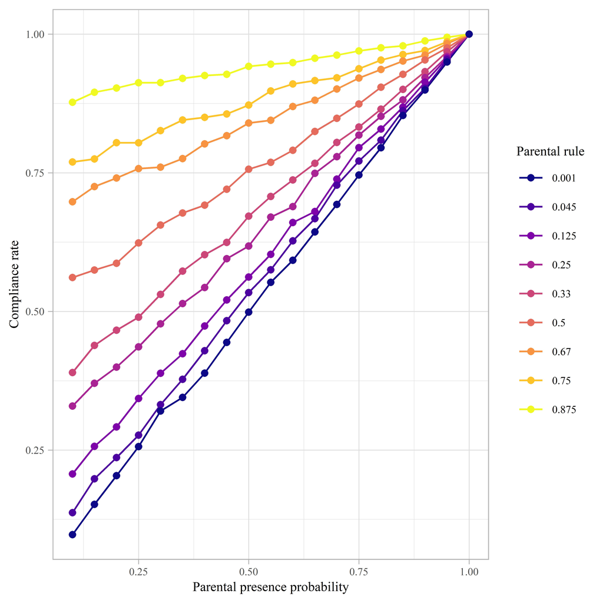

Compliance rate in 1000 simulation steps vs. different P_Probability parameters in the FC_P_PC_A compliance mode (created using the code Exploring_Compliance.R)

As the above figure shows, increasing the number of Presence steps always increases compliance, although at a different rate for various rules. Here, we aim to model the types of adolescents who would comply more when constantly monitored and pushed by their parents. Note that this compliance does not necessarily result in better performance and better building up of appropriate attractors. We discuss these cases in the section Update_StateVariables submodel.

The equations of the CLP and the CLA of the PC_P_NC_A compliance mode are as follows:

$$\small
Compliance\:likelihood =
\begin{cases}
1 - P\_Probability \times (1 - Rule) & \quad Presence =
TRUE\\
0 & \quad Presence = FALSE
\end{cases}$$

Here, as the rules get stricter and the parent agent’s Presence increases, the compliance likelihood of the adolescent agent declines. The overall compliance rate in this mode is depicted in the image below for different P_Probability parameters (again, we have averaged the compliance rates in 1000 simulation steps across five runs).

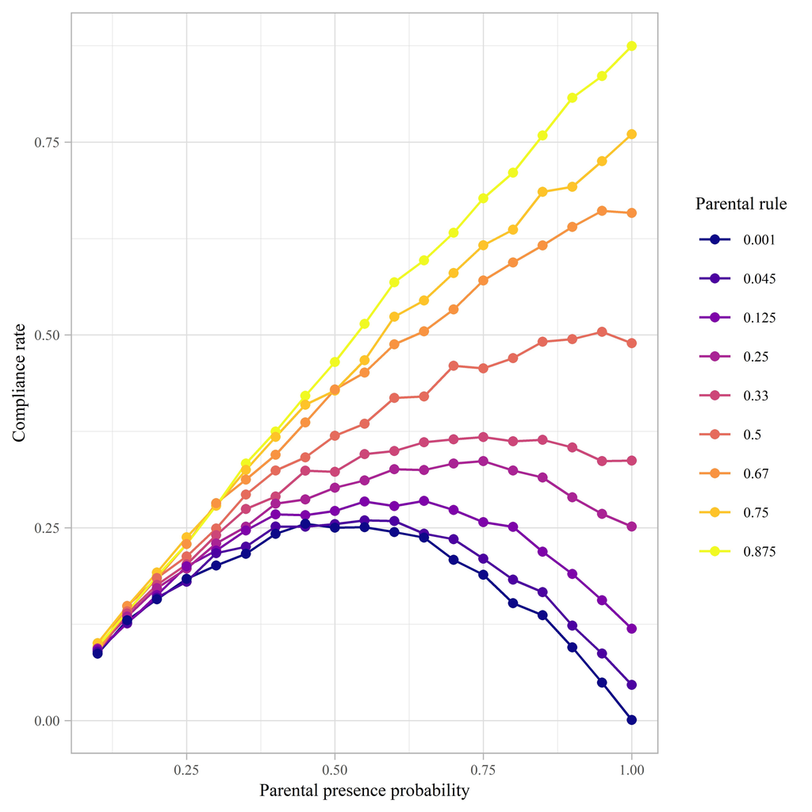

Compliance rate in 1000 simulation steps vs. different P_Probability parameters in the PC_P_NC_A compliance mode (created using the code Exploring_Compliance.R)

In this mode, for lax rules, increasing the Presence steps results in an increase in compliance. However, as the rules become stricter, more Presence steps fail to illicit higher compliance, and highly strict rules even lead to lower compliance. The rationale behind this implementation is to account for instances where rigid rule-setting results in defiance.

Note that the CLP and the CLA are constant values, initialized before the simulation loop begins, and do not change during the entire simulation.

## 6.3 Execute_Action submodel

This submodel (refer to the code Execute_Action.R) consists of three functions that run in the following order:

1. Select_Action
2. Enforce_Parental_Rule
3. Generate_Output

We describe each function in detail in the sections that follow.

### 6.3.1 Select_Action function

This function (refer to the code Select_Action.R) selects an action (a goal) and outputs its index. The selections in this function are intrinsic, without considering external constraints and circumstances. In other words, this is what the person would want to do, had she been free to do just as she wished for.

Individuals pursue multiple goals in their daily activities. Moreover, these goals span a wide range of domains and time frames. To focus on the core processes of the target system and keep the implementation as simple as possible, in this model, we conflate all these multitudes of goals into a long-term and a short-term one. At each simulation step, the adolescent agent selects an action associated with either of these goals, abbreviated as LG and SG, respectively. We have chosen these two types to represent the common goals studied in the self-control literature. The LG represents goals that require effort in the present and bear their fruit in the future. On the other hand, the SG characterizes fun activities and desires which are satisfying at the moment but may hinder pursuing long-term, more beneficial goals.

Moreover, in many instances, a person can perform multiple actions to achieve a single goal. Yet, since our focus is mainly on the differences between goal types and not their corresponding actions, we assume there is only one action per goal. Therefore, in this model, action selection and goal selection are synonymous.

Choosing which goal to attend to in the next couple of minutes depends on various factors, the significance of which varies temporally and situationally. In their Whole Trait Theory, Fleeson & Jayawickreme (2015) categorize these factors into interpretive, motivational, stability-inducing, temporal, and random error processes. The interpretive aspect refers to the cognitive processing of the available information, and the motivational one directs the individual toward or away from certain end states. On the other hand, the stability-inducing processes facilitate trait manifestations via homeostatic or habitual forces. Moreover, the temporal aspect captures the effect of previous choices on the current selection. Finally, by including a random error process, we could account for the unpredictable factors affecting the tendency to attend to various goals. To simplify the implementation and analysis of the model, we have included three of these five categories in our action selection process. In this regard, we have associated each goal with two criteria:

- **The Goal Preference Probability (GPP)**
- **The State-Goal Link (SGL)**

Each goal is associated with a constant Goal Preference Probability or GPP. The GPP represents the general intrinsic appeal of an end state to the person. We can relate this criteria to the motivational aspect of the above categorization. In our model, all things being equal, higher GPP entails a higher probability of selecting the corresponding goal. Moreover, we have considered complementary GPPs for the two goals implemented in this model. For instance, with a GPP of 0.2 for the LG, the GPP of the SG would be 0.8.

In addition, we associate short-term goals with higher autonomous motivations than long-term ones. Based on the principles of the self-determination theory (Ryan & Deci, 2000), we could say that the higher the intrinsic motivation toward a goal, the more likely the person would choose to execute actions to fulfill it. Therefore, the higher preference for short-term goals entails that the agent would be more likely to choose them over the long-term ones. We explore the impact of different values of this parameter in the systematic experiments of the model.

We include the SGL, defined in terms of dynamic systems concepts, to account for the stability-inducing aspects of choosing to act toward a goal. For more details on the theoretical aspects of the State-Goal links, refer to Basic concepts. Moreover, we explain the implementation details of this factor in the Update_StateVariables submodel.

These two criteria are combined to form scores for each of the goals:

$$\small
G\_Score = GPP + SGL\_Weight \times SGL$$

Where the parameter *SGL_Weight* captures the relative weight of the two criteria. We also explore the impacts of different levels of this parameter on the outcome.

Next, we calculate the proportional scores of the two goals and use these scores as the probability of choosing either one of the goals in a weighted random selection. As explained above, by introducing randomness, we aim to account for the unpredictable factors that influence the action selection process in real life.

As evident, we have not included the interpretive and temporal aspects of Fleeson’s and Jayawickreme’s (2015) categorization in our action selection process. The rationale, again, is to simplify the model processes by avoiding complex planning and cognitive appraisals. More importantly, we have assumed that the previous choices do not affect subsequent ones. Such an assumption, of course, does not hold in real life, and yet, it reduces the complexities of model analysis. Later versions could be more realistic by including these additional factors.

To better understand this function’s procedure, consider the following example:

- LG preference probability = 0.2
- SG preference probability = 0.8
- SGL_Weight = 4.5
- SGL for the LG = 0.35
- SGL for the SG = 0.25

With these values, the LG would have a score of 1.775 ($\small 0.2 + 4.5 \times 0.35$), and the SG would have a score of 1.925 ($\small 0.8 + 4.5 \times 0.25$). Therefore, the proportional score of the LG and the SG would be 0.48 and 0.52, respectively. We use these proportional scores as the probabilities of choosing either of the goals in a weighted random selection. In other words, in this process, the LG would have a 48% and the SG would have a 52% chance of getting selected.

### 6.3.2 Enforce_Parental_Rule function

This function (refer to the code Enforce_Parental_Rule.R) determines whether the parent agent allows the execution of the selected action. The output is a binary variable, where TRUE indicates that the parent agent approves the selected action, and FALSE indicates otherwise. The latter case would then mean that the action needs to change.

Before the simulation loop begins, the parental rule (for more information, refer to the Determine_Compliance submodel) is converted into an SG limit in every 24 simulation steps (representing 12 working hours per day). For example, a rule of 0.75 translates into an *SG_Limit* equal to 18, meaning that out of every 24 actions, the adolescent has to execute at least 6 LG ones, while she can dedicate the other 18 to SG actions.

However, the adolescent agent only complies with the parents’ rule when its *Compliance_State* is TRUE. Therefore, to comply with the parental rule, the adolescent agent counts the number of executed SG actions in every 24 consecutive simulation steps where the Compliance_State is TRUE.

At the beginning, the function checks the Compliance_State variable and if it is FALSE, regardless of the parental rule, the function returns a TRUE value and approves the action. On the other hand, when the Compliance_State is TRUE, the function proceeds to check the selected action against the parental rule.

First, the variable *CS_Counter* counts the compliance steps and is reset whenever it reaches the constant *Reset_Steps* (equal to 24). Next, the function checks the action. When the adolescent agent has selected an LG action, the function outputs a TRUE value. Otherwise, the variable *SG_Counter* is compared to the constant *SG_Limit*. If it exceeds the *SG_Limit*, the function returns with a FALSE value, disapproving the action. If not, the *SG_Counter* is incremented by one, and the function returns with a TRUE value, approving the action.

### 6.3.3 Generate_Output function

This function (refer to the code Generate_Output.R) returns the index of the action that should be executed, along with a binary variable that indicates whether this action was a forced choice.

This function receives the output of the function Enforce_Parental_Rule, or the *Approval_Status*, as its input. When the Approval_Status is TRUE, the *Executed_Action* is set to the *Selected_Action*, and the *Forced_Choice* is set to FALSE. Otherwise, the Executed_Action would be the LG action, and the Forced_Choice is set to TRUE. Note that only SG actions can fail to get approval, and in such cases, the only choice would be to change them to LG ones.

## 6.4 Update_StateVariables submodel

This submodel (refer to the code Update_StateVariables.R) updates the adolescent agent’s state variables, **SLG_Link** and **SSG_Link**. These state variables are matrices containing the value of each of the two goals’ state spaces. In this section, we discuss the implementation details of these state variables, for a theoretical view of these concepts refer to Basic concepts.

As discussed in the Basic concepts section, executing an action can strengthen the link between its corresponding goal and the agent’s current state within the state space. As the simulation proceeds, executing actions in each step shapes the state space by changing the value of the elements of its corresponding matrix.

In this work, our focus is on the volitional execution of actions. Based on the literature discussed in detail in the introduction of the main article, autonomous action execution results in higher internalization of values. Therefore, we use the volition score of the action as a feedback to reinforce its link with the states within the state space.

As discussed in the Execute_Action submodel, the adolescent agent can either execute its self-selected action or has to change it to comply with the parental rule. The first case, reflecting a fully autonomous action execution, leads to the highest feedback value of 1. On the other hand, being forced to engage in other activities results in lower feelings of autonomy. In this work, we have chosen a simple representation of this relationship by using the following equation for the *Perceived_Autonomy* of an adolescent agent, where stricter rules and higher presence probabilities (reflected in the parameter *P_Probability*) result in lower Perceived_Autonomy, which remains constant through the simulation:

$$\small
Perceived\_Autonomy = Rule - P\_Probability \times (1 - Rule) > 0$$

After the execution of an action at each step, the value of the current state position of the corresponding goal is decremented either by 1, in case of executing the self-selected action, or by the Perceived_Autonomy, in case of a forced choice. We *decrease* the value of each state to create *valleys* in the state space structure. However, representing attractors by valleys is merely for illustrative purposes, and the sign of the values in the state space does not bear any special meaning.

Note that different equations can describe the link between adolescents’ perceived autonomy, parents’ rule-setting, and monitoring activities and how these affect the internalization of a set of values in the adolescent. Generally, this field’s studies point to a positive association between parents’ autonomy support and adolescents’ internalization of the values. However, the exact processes leading to these results are not often discussed. On the other hand, in a computational model, we have no choice but to specify the relation between model components in clear equations. Therefore, by this choice of the link between parental rule-setting and rule enforcement and adolescents’ internalization of values, rather than providing an exact representation, we aim to capture the general picture of the involved processes.

## 6.5 Choose_Next_SSP submodel

This submodel (refer to the code Choose_Next_SSP.R) determines the new position of the adolescent agent in its state space.

The adolescent agent’s next state space position is initially determined using a random process that draws the coordinates of the new point from a normal distribution. Numerous internal and external factors can influence the state of an individual. Therefore, to avoid further complications of the model, we have chosen to use a random selection to account for this multitude of influencing factors. Moreover, a random selection process using a normal distribution with a mean positioned at the center of the state space would choose central positions more frequently. First, it’s worth noting that there are no initial and fundamental differences between the various state positions in the agent’s state space. However, by choosing this random process, the agent would have a lower likelihood of visiting the edges of the state space. These edge states could be interpreted as *extreme* values, which are, in fact, rarer than average ones. Also note that in the current implementation, the previous state position has no impact on the next.

After specifying the initial next position, we examine the destination point’s (DP) neighborhood for the local minimum. The idea here is that entering the basin of an attractor leads to being pulled toward the attractor. In this model, the positions with lower State-Goal link (SGL) values represent deeper attractors. Therefore, the system tends to take up the position of the nearest local minimum, like a ball that comes to rest in the nearest valley.

Searching for the local minimum is performed using an iterative process. First, we examine the immediate vicinity of the initial DP. If the neighboring points have higher or equal values of the SGL, the initial DP becomes the final state space position. However, if one of these points has lower SGL values, the position shifts, and the function searches the neighborhood of this new position. The process continues until the target position has the lowest SGL among its surrounding states.

# 7 References

Fleeson, W., & Jayawickreme, E. (2015). Whole trait theory. *Journal of Research in Personality*, *56*, 82–92. https://doi.org/10.1016/j.jrp.2014.10.009

Grimm, V., Berger, U., Bastiansen, F., Eliassen, S., Ginot, V., Giske, J., Goss-Custard, J., Grand, T., Heinz, S. K., Huse, G., Huth, A., Jepsen, J. U., Jørgensen, C., Mooij, W. M., Müller, B., Pe’er, G., Piou, C., Railsback, S. F., Robbins, A. M., … DeAngelis, D. L. (2006). A standard protocol for describing individual-based and agent-based models. *Ecological Modelling*, *198*, 115–126. https://doi.org/10.1016/J.ECOLMODEL.2006.04.023

Hinnant, J. B., Erath, S. A., Tu, K. M., & El-Sheikh, M. (2016). Permissive parenting, deviant peer affiliations, and delinquent behavior in adolescence: The moderating role of sympathetic nervous system reactivity. *Journal of Abnormal Child Psychology*, *44*, 1071–1081. https://doi.org/10.1007/S10802-015-0114-8/FIGURES/4

Karmakar, R. (2015). Does parenting style influence the internalization of moral values in children and adolescents? *Psychological Studies*, *60*, 438–446. https://doi.org/10.1007/s12646-015-0338-2

Newell, K. M., Liu, Y. T., & Mayer-Kress, G. (2003). A dynamical systems interpretation of epigenetic landscapes for infant motor development. *Infant Behavior and Development*, *26*, 449–472. https://doi.org/10.1016/J.INFBEH.2003.08.003

Ryan, R. M., & Deci, E. L. (2000). Self-determination theory and the facilitation of intrinsic motivation, social development, and well-being. *American Psychologist*, *55*, 68–78. https://doi.org/10.1037/0003-066X.55.1.68

Sandamirskaya, Y., Zibner, S. K. U., Schneegans, S., & Schöner, G. (2013). Using dynamic field theory to extend the embodiment stance toward higher cognition. *New Ideas in Psychology*, *31*, 322–339. https://doi.org/10.1016/J.NEWIDEAPSYCH.2013.01.002

Stamovlasis, D. (2016). Catastrophe theory: Methodology, epistemology, and applications in learning science. In *Complex Dynamical Systems in Education: Concepts, Methods and Applications* (pp. 141–175). Springer International Publishing. https://doi.org/10.1007/978-3-319-27577-2_9/COVER

Thomas, K. J., Rodrigues, H., Oliveira, R. T. de, & Mangino, A. A. (2020). What predicts pre-adolescent compliance with family rules? A longitudinal analysis of parental discipline, procedural justice, and legitimacy evaluations. *Journal of Youth and Adolescence*, *49*, 936–950. https://doi.org/10.1007/s10964-019-01158-0

van Petegem, S., Zimmer-Gembeck, M., Baudat, S., Soenens, B., Vansteenkiste, M., & Zimmermann, G. (2019). Adolescents’ responses to parental regulation: The role of communication style and self-determination. *Journal of Applied Developmental Psychology*, *65*, 101073. https://doi.org/10.1016/J.APPDEV.2019.101073

Vansteenkiste, M., Soenens, B., Petegem, S. V., & Duriez, B. (2014). Longitudinal associations between adolescent perceived degree and style of parental prohibition and internalization and defiance. *Developmental Psychology*, *50*, 229–236. https://doi.org/10.1037/a0032972

Won, S., & Yu, S. L. (2018). Relations of perceived parental autonomy support and control with adolescents’ academic time management and procrastination. *Learning and Individual Differences*, *61*, 205–215. https://doi.org/10.1016/j.lindif.2017.12.001